# In class examples - 15.03.2022

```r
# install.packages("devtools")
# devtools::install_github("https://github.com/SMAC-Group/idar")

# Import data
library(idar)
data(diet)

# Compute weight loss
diet$weight.loss = diet$initial.weight - diet$final.weight

# Select diet
posw = diet$diet.type=="B"

# Variable of interest
X = diet$weight.loss[posw]

# A first look...
head(X)
```

```
## [1] -2.1  2.0  1.7  4.3  7.0  0.6
```

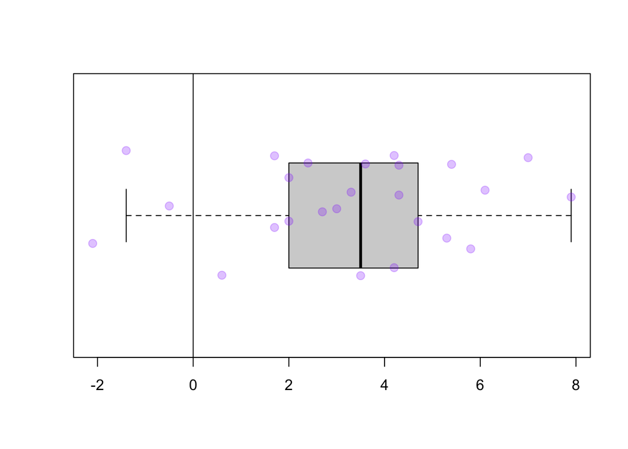

```r
# Let's see the data...
boxplot_w_points(X, horizontal = T)
abline(v = 0)
```

## T-test

Then, we consider the test:

$$H_0: \;\; \mu = 0,\;\;\; H_a: \;\; \mu > 0$$

based on $\alpha = 0.05$:

```r
t.test(X, mu = 0, alternative = "greater")
```

```
##
##  One Sample t-test
##
## data:  X
## t = 6.6301, df = 24, p-value = 3.697e-07
## alternative hypothesis: true mean is greater than 0
## 95 percent confidence interval:
##  2.424694      Inf
## sample estimates:
## mean of x
##     3.268
```

Based on the p-value we obtained, we can reject the null and accept the alternative.

We can also consider the following test:

$$H_0: \;\; \mu = 2,\;\;\; H_a: \;\; \mu > 2$$

```r
t.test(X, mu = 2, alternative = "greater")
```

```
##
##  One Sample t-test
##
## data:  X
## t = 2.5725, df = 24, p-value = 0.008355
## alternative hypothesis: true mean is greater than 2
## 95 percent confidence interval:
##  2.424694      Inf
## sample estimates:
## mean of x
##     3.268
```

In this case, we can also reject the null and accept the alternative, however, this is not the case if we consider:

$$H_0: \;\; \mu = 3,\;\;\; H_a: \;\; \mu > 3$$

```r
t.test(X, mu = 3, alternative = "greater")
```

```
##
##  One Sample t-test
##
## data:  X
## t = 0.54371, df = 24, p-value = 0.2958
## alternative hypothesis: true mean is greater than 3
## 95 percent confidence interval:
##  2.424694      Inf
## sample estimates:
## mean of x
##     3.268
```

## Wilcoxon test

In this example we obtain very similar results by using Wilcoxon test instead of the t-test:

```r
wilcox.test(X, mu = 0, alternative = "greater")
```

```
##
##  Wilcoxon signed rank test with continuity correction
##
## data:  X
## V = 313, p-value = 2.71e-05
## alternative hypothesis: true location is greater than 0
```

```r
wilcox.test(X, mu = 2, alternative = "greater")
```

```
##
##  Wilcoxon signed rank test with continuity correction
##
## data:  X
## V = 213.5, p-value = 0.01126
## alternative hypothesis: true location is greater than 2
```

```r
wilcox.test(X, mu = 3, alternative = "greater")
```

```
##
##  Wilcoxon signed rank test with continuity correction
##
## data:  X
## V = 176.5, p-value = 0.2286
## alternative hypothesis: true location is greater than 3
```

## Illustration of the difference between t-test and Wilcoxon test

To illustrate the difference between the two tests, we artificially change the smallest value (which -2.1) to -20. This can be done as follows:

```r
X[which.min(X)] = -20
```

By doing so, we introduce one outlier in the data as can be observed in the graph below:

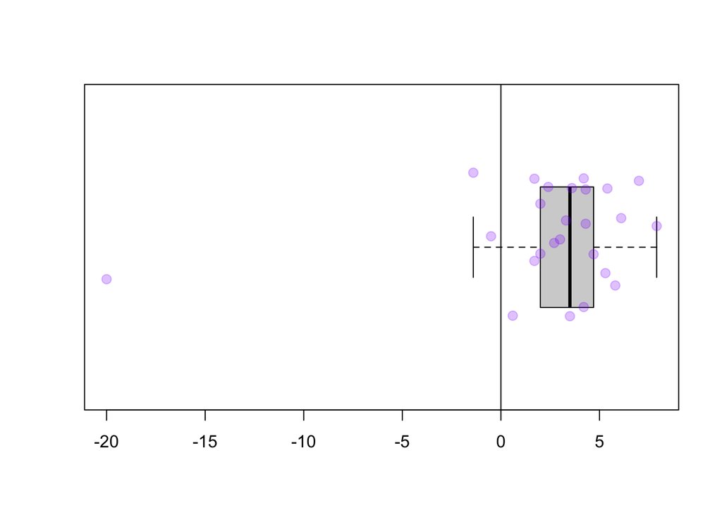

```r
boxplot_w_points(X, horizontal = T)
abline(v = 0)
```

Suppose we consider the hypotheses:

$$H_0: \;\; \mu = 2,\;\;\; H_a: \;\; \mu > 2$$

and recall that before adding one artificial “outlier” the p-values of both t-test and Wilcoxon test were smaller than $\alpha$ (0.8355% and 1.126% respectively). Let’s see if this is still case now:

```r
t.test(X, mu = 2, alternative = "greater")
```

```
##
##  One Sample t-test
##
## data:  X
## t = 0.53217, df = 24, p-value = 0.2997
## alternative hypothesis: true mean is greater than 2
## 95 percent confidence interval:
##  0.777374      Inf
## sample estimates:
## mean of x
##     2.552
```

```r
wilcox.test(X, mu = 2, alternative = "greater")
```

```
##
##  Wilcoxon signed rank test with continuity correction
##
## data:  X
## V = 211.5, p-value = 0.01318
## alternative hypothesis: true location is greater than 2
```

As expected the p-value based on the t-test is heavily influenced by the outlier (changing from 0.8355% to 29.97%) while this is not the case for Wilcoxon test (only changing from 1.126% to 1.318%).